# Project 4: Movie Recommendation Report

Zhouning Ma (ZM11)

Dec 08,2020

### Project Overview

In this project, we develop content based recommendation system(System I) and collaborative recommendation system(System II) [1].

- **System I:** recommendation based on genres. We know user’s favorite genre, we provide two recommendation schemes:
  - **Method I:** highly-rate movies - select the 4-point or more review
  - **Method II:** most trendy movies - the newest movie(here is year 2000)
- **System II:** collaborative recommendation system. we provided three collaborative recommendation algorithms:
  - **User-based (UBCF):** we assume that similar users will have similar taste. UBCF uses the logic and recommends items by finding similar users to the user;
  - **Item-based (IBCF):** The similarities between different items in the dataset are calculated by using one of a number of similarity measures, and then these similarity values are used to predict;
  - **Singular value decomposition (SVD):** It uses a matrix structure where each row represents a user, and each column represents an item. The elements of this matrix are the ratings that are given to items by users.

### Dataset

- Number of movies: $3883$
- Number of ratings: $244229$
- Number of users: $1510$

The dataset README[3] shows: Genres are pipe-separated and are selected from the following genres:

- Action
- Adventure
- Animation
- Children’s
- Comedy
- Crime
- Documentary
- Drama
- Fantasy
- Film-Noir
- Horror
- Musical
- Mystery
- Romance
- Sci-Fi
- Thriller
- War
- Western

The movies’ year are between $1919$ to $2000$.

### Exploring Similarity Data

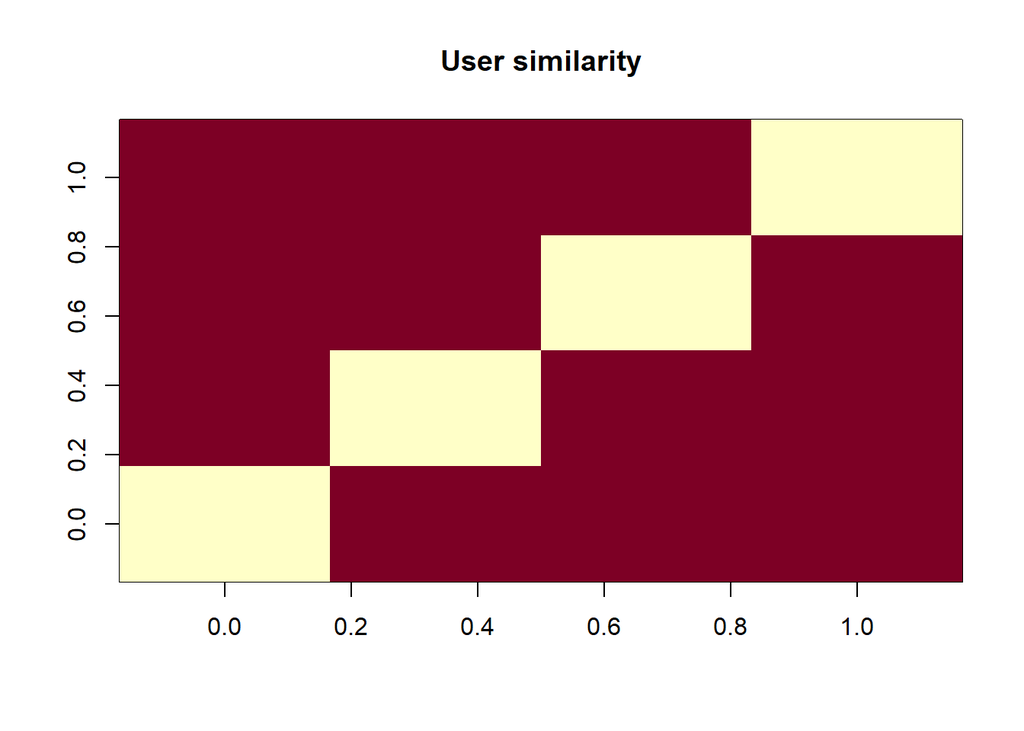

```r
image(as.matrix(similarity_users), main = "User similarity")
```

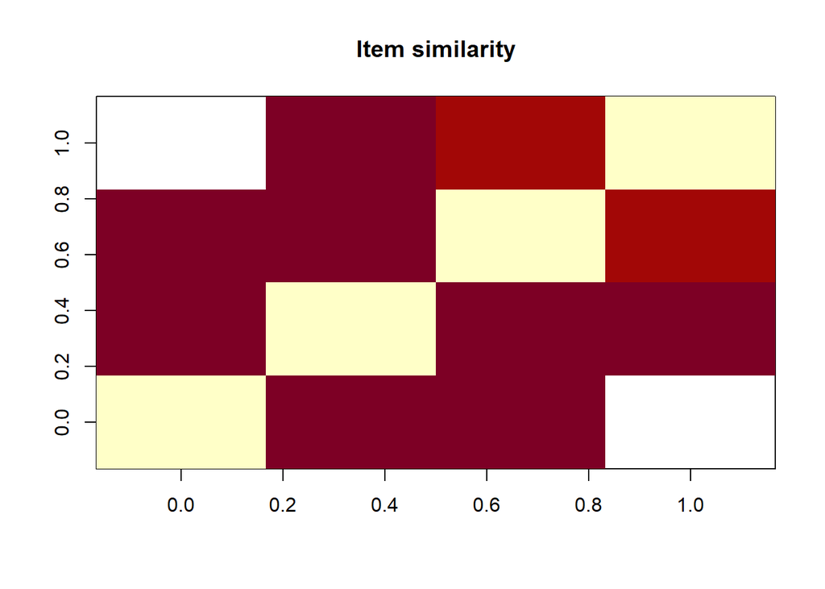

```r
image(as.matrix(similarity_items), main = "Item similarity")
```

### Most Viewed Movies Visualization [4][5]

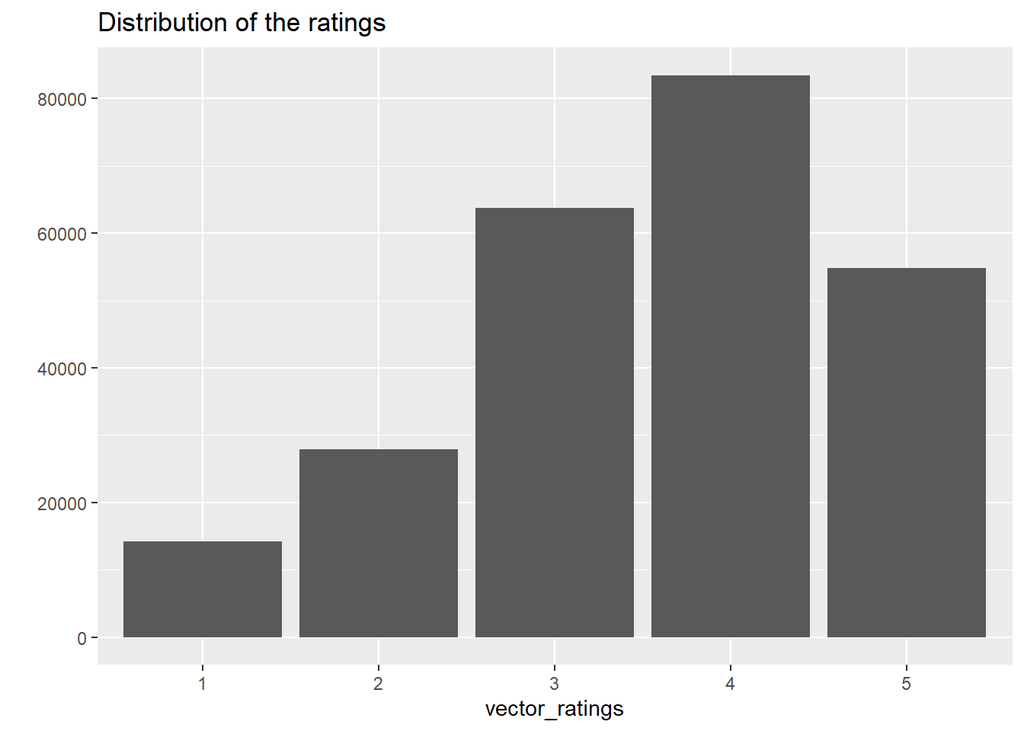

```r
# Visualize the rating:
vector_ratings <- vector_ratings[vector_ratings != 0] # rating == 0 are NA values
vector_ratings <- factor(vector_ratings)

qplot(vector_ratings) +
  ggtitle("Distribution of the ratings")
```

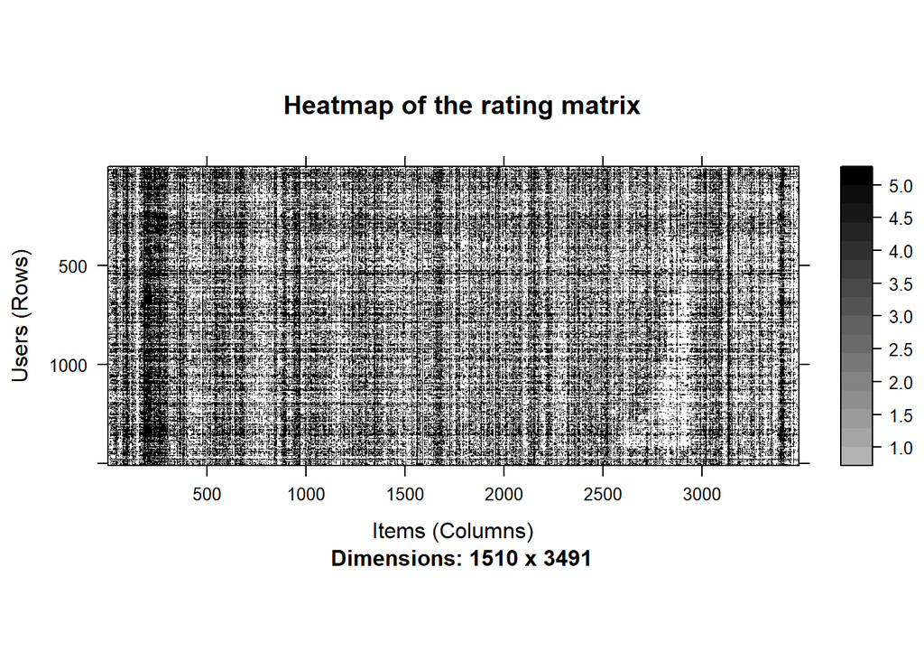

```r
#Visualizing the matrix:
image(ratingmat, main = "Heatmap of the rating matrix") # hard to read-too many dimensions
```

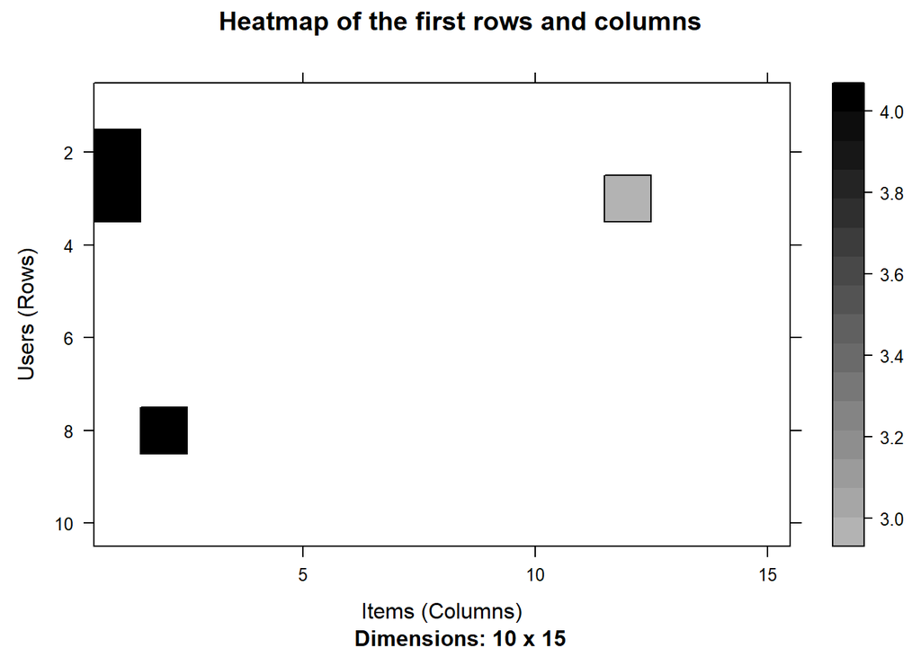

```r
image(ratingmat[1:10, 1:15], main = "Heatmap of the first rows and columns")
```

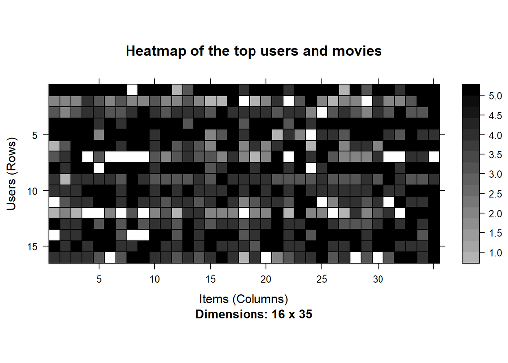

```r
image(ratingmat[rowCounts(ratingmat) > quantile(rowCounts(ratingmat), 0.99),
                 colCounts(ratingmat) > quantile(colCounts(ratingmat), 0.99)],
      main = "Heatmap of the top users and movies")
```

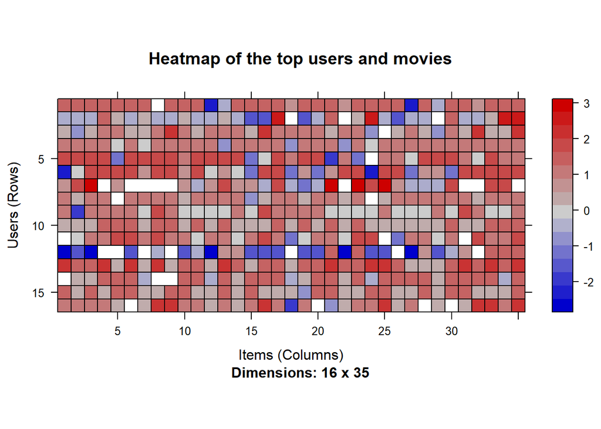

```r
#Normalize the data
ratingmat_norm <- normalize(ratingmat)
image(ratingmat_norm[rowCounts(ratingmat_norm) > quantile(rowCounts(ratingmat_norm), 0.99),
                colCounts(ratingmat_norm) > quantile(colCounts(ratingmat_norm), 0.99)],
      main = "Heatmap of the top users and movies")
```

## System I

system I is content based recommendation system, let’s say we know the user’s favorite genres, we will recommend movies based on genres.

### Method I: highly-rate movies

We calculate the average point of each movie and randomly pick N movies which average point is great than 3-point(4-point or 5-point) in the genres.

```r
  # Method 1:
  numberofmovierecommend = 5

  input_genre1 = genre_list[1]
  input_genre2 = genre_list[2]
  input_genre3 = genre_list[3]

  systemresult = subset(moviesList,AveRating>=4 & (grepl(input_genre1, genres, fixed = TRUE) | grepl(input_genre2, genres, fixed = TRUE) | grepl(input_genre3, genres, fixed = TRUE)) )
  if (nrow(systemresult) < numberofmovierecommend){
     systemresult = subset(moviesList, grepl(input_genre1, genres, fixed = TRUE) | grepl(input_genre2, genres, fixed = TRUE) | grepl(input_genre3, genres, fixed = TRUE))
  }

  systemresult = systemresult[sample(nrow(systemresult), ifelse(nrow(systemresult)>=numberofmovierecommend,numberofmovierecommend,nrow(systemresult))),]
  systemresult
```

```
##      MovieID AveRating                     title
## 3681    3927         4   Fantastic Voyage (1966)
## 1051    1127         4         Abyss, The (1989)
## 2161    2353         4 Enemy of the State (1998)
## 2014    2194         4  Untouchables, The (1987)
## 3521    3763         4                F/X (1986)
##                                genres
## 3681                 Adventure|Sci-Fi
## 1051 Action|Adventure|Sci-Fi|Thriller
## 2161                  Action|Thriller
## 2014               Action|Crime|Drama
## 3521            Action|Crime|Thriller
```

### Method II:most trendy movies

The newest movies are year 2000 in the dataset, we will randomly pick N movies from year 2000 in the genres, Unfortunately sometimes there are not enough movies in year 2000 for each genres, for example, it is empty in genres “Film-Noir” of year 2000, we have to try the movies of year 1999.

```r
  # Method 2:
  numberofmovierecommend = 5
  trendyYear = 2000

  input_genre1 = genre_list[1]
  input_genre2 = genre_list[2]
  input_genre3 = genre_list[3]


  systemresult = subset(movies_clean, year >= trendyYear & (grepl(input_genre1, genres, fixed = TRUE) | grepl(input_genre2, genres, fixed = TRUE) | grepl(input_genre3, genres, fixed = TRUE)) )
  if (nrow(systemresult) < numberofmovierecommend){
      systemresult = subset(movies_clean, year >= trendyYear - 1 & (grepl(input_genre1, genres, fixed = TRUE) | grepl(input_genre2, genres, fixed = TRUE) | grepl(input_genre3, genres, fixed = TRUE)) )
  }
  systemresult = systemresult[sample(nrow(systemresult), ifelse(nrow(systemresult)>=numberofmovierecommend,numberofmovierecommend,nrow(systemresult))),]
  systemresult
```

```
##      MovieID                       title year                      genres
## 2106    3751          Chicken Run (2000) 2000 Animation|Children's|Comedy
## 2322    3753         Patriot, The (2000) 2000            Action|Drama|War
## 2607    3793                X-Men (2000) 2000               Action|Sci-Fi
## 1375    3744                Shaft (2000) 2000                Action|Crime
## 1032    3563 Crow: Salvation, The (2000) 2000               Action|Horror
```

## System II

### Create realRatingMatrix

```r
ratings <- as(ratings, 'realRatingMatrix')
```

### Training and Testing Data

We split the data into 80% training and 20% testing.

```r
train_proportion <- 0.8
folds <-10
to_keep <- 15  ## given 15 items
threshold <- 0 ## ratings above 0 as the cutoff point

# split the data into the training and the test set:
e <- evaluationScheme(ratings, method="split", train=train_proportion, k=folds, given=to_keep, goodRating=threshold)
e
```

```
## Evaluation scheme with 15 items given
## Method: 'split' with 10 run(s).
## Training set proportion: 0.800
## Good ratings: >=0.000000
## Data set: 1510 x 3491 rating matrix of class 'realRatingMatrix' with 244229 ratings.
```

### Train User-based and Item-based Collaborative Filtering models

We will train CF models by difference parameters [7][8]:

- normalize: NULL, center or Z-score;
- method: Cosine, Euclidean pearson

also, we will train two SVD models with difference parameter, total **20 models:**, we will calculate prediction accuracy as well, the following are the examples:

#### User-Based Collaborative Filtering: Cosine Similarity

- UBCF_N_C : The raw data is used with no normalization applied;
- UBCF_C_C: Data are normalized using centering.
- UBCF_Z_C: Z-score normalization is applied to the data;

```r
# train UBCF cosine similarity models
# non-normalized
UBCF_N_C <- Recommender(getData(e, "train"), "UBCF", param=list(normalize = NULL, method="Cosine"))

# centered
UBCF_C_C <- Recommender(getData(e, "train"), "UBCF", param=list(normalize = "center",method="Cosine"))

# Z-score normalization
UBCF_Z_C <- Recommender(getData(e, "train"), "UBCF", param=list(normalize = "Z-score",method="Cosine"))
```

```r
#Evaluate the models:

# compute predicted ratings
p1 <- predict(UBCF_N_C, getData(e, "known"), type="ratings")
p2 <- predict(UBCF_C_C, getData(e, "known"), type="ratings")
p3 <- predict(UBCF_Z_C, getData(e, "known"), type="ratings")

# aggregate the performance statistics
error_UCOS <- rbind(
  UBCF_N_C = calcPredictionAccuracy(p1, getData(e, "unknown")),
  UBCF_C_C = calcPredictionAccuracy(p2, getData(e, "unknown")),
  UBCF_Z_C = calcPredictionAccuracy(p3, getData(e, "unknown"))
)
kable(error_UCOS)
```

|  | RMSE | MSE | MAE |
| --- | --- | --- | --- |
| UBCF_N_C | 1.215148 | 1.476584 | 0.9243005 |
| UBCF_C_C | 1.187894 | 1.411093 | 0.9304944 |
| UBCF_Z_C | 1.192298 | 1.421574 | 0.9213753 |

#### User-Based Collaborative Filtering: Euclidean Distance

```r
# train UBCF Euclidean Distance models

# non-normalized
UBCF_N_E <- Recommender(getData(e, "train"), "UBCF", param=list(normalize = NULL, method="Euclidean"))

# centered
UBCF_C_E <- Recommender(getData(e, "train"), "UBCF", param=list(normalize = "center",method="Euclidean"))

# Z-score normalization
UBCF_Z_E <- Recommender(getData(e, "train"), "UBCF", param=list(normalize = "Z-score",method="Euclidean"))
```

```r
# compute predicted ratings
p1 <- predict(UBCF_N_E, getData(e, "known"), type="ratings")
p2 <- predict(UBCF_C_E, getData(e, "known"), type="ratings")
p3 <- predict(UBCF_Z_E, getData(e, "known"), type="ratings")

# aggregate the performance statistics
error_UEUC <- rbind(
  UBCF_N_E = calcPredictionAccuracy(p1, getData(e, "unknown")),
  UBCF_C_E = calcPredictionAccuracy(p2, getData(e, "unknown")),
  UBCF_Z_E = calcPredictionAccuracy(p3, getData(e, "unknown"))
)
kable(error_UEUC)
```

|  | RMSE | MSE | MAE |
| --- | --- | --- | --- |
| UBCF_N_E | 1.188336 | 1.412143 | 0.9038894 |
| UBCF_C_E | 1.174373 | 1.379152 | 0.9068344 |
| UBCF_Z_E | 1.190146 | 1.416447 | 0.9161579 |

#### User-Based Collaborative Filtering: Pearson Correlation

```r
#train UBCF pearson correlation models

# non-normalized
UBCF_N_P <- Recommender(getData(e, "train"), "UBCF", param=list(normalize = NULL, method="pearson"))

# centered
UBCF_C_P <- Recommender(getData(e, "train"), "UBCF", param=list(normalize = "center",method="pearson"))

# Z-score normalization
UBCF_Z_P <- Recommender(getData(e, "train"), "UBCF", param=list(normalize = "Z-score",method="pearson"))
```

```r
# compute predicted ratings
p1 <- predict(UBCF_N_P, getData(e, "known"), type="ratings")
p2 <- predict(UBCF_C_P, getData(e, "known"), type="ratings")
p3 <- predict(UBCF_Z_P, getData(e, "known"), type="ratings")

# aggregate the performance statistics
error_UPC <- rbind(
  UBCF_N_P = calcPredictionAccuracy(p1, getData(e, "unknown")),
  UBCF_C_P = calcPredictionAccuracy(p2, getData(e, "unknown")),
  UBCF_Z_P = calcPredictionAccuracy(p3, getData(e, "unknown"))
)
kable(error_UPC)
```

|  | RMSE | MSE | MAE |
| --- | --- | --- | --- |
| UBCF_N_P | 1.168335 | 1.365007 | 0.9046888 |
| UBCF_C_P | 1.148867 | 1.319894 | 0.8987414 |
| UBCF_Z_P | 1.145786 | 1.312825 | 0.8874046 |

#### Item-Based Collaborative Filtering: Cosine Similarity

```r
#train IBCF cosine similarity models

# non-normalized
IBCF_N_C <- Recommender(getData(e, "train"), "IBCF", param=list(normalize = NULL, method="Cosine"))

# centered
IBCF_C_C <- Recommender(getData(e, "train"), "IBCF", param=list(normalize = "center",method="Cosine"))

# Z-score normalization
IBCF_Z_C <- Recommender(getData(e, "train"), "IBCF", param=list(normalize = "Z-score",method="Cosine"))
```

```r
# compute predicted ratings
p1 <- predict(IBCF_N_C, getData(e, "known"), type="ratings")
p2 <- predict(IBCF_C_C, getData(e, "known"), type="ratings")
p3 <- predict(IBCF_Z_C, getData(e, "known"), type="ratings")


# aggregate the performance statistics
error_ICOS <- rbind(
  IBCF_N_C = calcPredictionAccuracy(p1, getData(e, "unknown")),
  IBCF_C_C = calcPredictionAccuracy(p2, getData(e, "unknown")),
  IBCF_Z_C = calcPredictionAccuracy(p3, getData(e, "unknown"))
)

kable(error_ICOS)
```

|  | RMSE | MSE | MAE |
| --- | --- | --- | --- |
| IBCF_N_C | 1.560552 | 2.435323 | 1.186284 |
| IBCF_C_C | 1.602043 | 2.566541 | 1.216056 |
| IBCF_Z_C | 1.637920 | 2.682783 | 1.275668 |

#### Item-Based Collaborative Filtering: Euclidean Distance

```r
#train IBCF Euclidean Distance models

# non-normalized
IBCF_N_E <- Recommender(getData(e, "train"), "IBCF", param=list(normalize = NULL, method="Euclidean"))

# centered
IBCF_C_E <- Recommender(getData(e, "train"), "IBCF", param=list(normalize = "center",method="Euclidean"))

# Z-score normalization
IBCF_Z_E <- Recommender(getData(e, "train"), "IBCF", param=list(normalize = "Z-score",method="Euclidean"))
```

```r
# compute predicted ratings
p1 <- predict(IBCF_N_E, getData(e, "known"), type="ratings")
p2 <- predict(IBCF_C_E, getData(e, "known"), type="ratings")
p3 <- predict(IBCF_Z_E, getData(e, "known"), type="ratings")


# aggregate the performance statistics
error_IEUC <- rbind(
  IBCF_N_E = calcPredictionAccuracy(p1, getData(e, "unknown")),
  IBCF_C_E = calcPredictionAccuracy(p2, getData(e, "unknown")),
  IBCF_Z_E = calcPredictionAccuracy(p3, getData(e, "unknown"))
)
kable(error_IEUC)
```

|  | RMSE | MSE | MAE |
| --- | --- | --- | --- |
| IBCF_N_E | 1.456224 | 2.120590 | 1.118586 |
| IBCF_C_E | 1.462784 | 2.139738 | 1.126638 |
| IBCF_Z_E | 1.462784 | 2.139738 | 1.126638 |

#### Item-Based Collaborative Filtering: Pearson Correlation

```r
#train IBCF pearson correlation models

# non-normalized
IBCF_N_P <- Recommender(getData(e, "train"), "IBCF", param=list(normalize = NULL, method="pearson"))

# centered
IBCF_C_P <- Recommender(getData(e, "train"), "IBCF", param=list(normalize = "center",method="pearson"))

# Z-score normalization
IBCF_Z_P <- Recommender(getData(e, "train"), "IBCF", param=list(normalize = "Z-score",method="pearson"))
```

```r
# compute predicted ratings
p1 <- predict(IBCF_N_P, getData(e, "known"), type="ratings")
p2 <- predict(IBCF_C_P, getData(e, "known"), type="ratings")
p3 <- predict(IBCF_Z_P, getData(e, "known"), type="ratings")

# aggregate the performance statistics
error_IPC <- rbind(
  IBCF_N_P = calcPredictionAccuracy(p1, getData(e, "unknown")),
  IBCF_C_P = calcPredictionAccuracy(p2, getData(e, "unknown")),
  IBCF_Z_P = calcPredictionAccuracy(p3, getData(e, "unknown"))
)
kable(error_IPC)
```

|  | RMSE | MSE | MAE |
| --- | --- | --- | --- |
| IBCF_N_P | 1.485537 | 2.206819 | 1.143831 |
| IBCF_C_P | 1.520329 | 2.311400 | 1.156737 |
| IBCF_Z_P | 1.470627 | 2.162742 | 1.115364 |

#### SVD models

- One is Latent-Factor Collaborative Filtering Recommender
- SVD with default parameter, we call it no-para

```r
# Latent-Factor Collaborative Filtering Recommender SVD
latent_factor_cofi_rec_SVD <- Recommender(data=getData(e, "train"), method="SVD",parameter=list(categories=30,normalize='center',method='Pearson'))
```

```
## Available parameter (with default values):
## k     =  10
## maxiter   =  100
## normalize     =  center
## verbose   =  FALSE
```

```r
# SVD with default parameters
no_para_svd <- Recommender(data=getData(e, "train"), method="SVD")
```

```r
# compute predicted ratings
p1 <- predict(latent_factor_cofi_rec_SVD, getData(e, "known"), type="ratings")
p2 <- predict(no_para_svd, getData(e, "known"), type="ratings")

# aggregate the performance statistics
error_SVD <- rbind(
  latent_factor_cofi_rec_SVD = calcPredictionAccuracy(p1, getData(e, "unknown")),
  no_para_SVD = calcPredictionAccuracy(p2, getData(e, "unknown"))
)
kable(error_SVD)
```

|  | RMSE | MSE | MAE |
| --- | --- | --- | --- |
| latent_factor_cofi_rec_SVD | 1.06531 | 1.134886 | 0.8529866 |
| no_para_SVD | 1.06531 | 1.134886 | 0.8529866 |

```r
# memory cleanup
rm(IBCF_N_P, IBCF_C_P, IBCF_Z_P)
```

```r
c_res <- data.frame(rbind(error_UCOS, error_UEUC, error_UPC, error_ICOS, error_IEUC, error_IPC, error_SVD))
c_res <- c_res[order(c_res$RMSE ),]
kable(c_res)
```

|  | RMSE | MSE | MAE |
| --- | --- | --- | --- |
| no_para_SVD | 1.065310 | 1.134886 | 0.8529866 |
| latent_factor_cofi_rec_SVD | 1.065310 | 1.134886 | 0.8529866 |
| UBCF_Z_P | 1.145786 | 1.312825 | 0.8874046 |
| UBCF_C_P | 1.148867 | 1.319894 | 0.8987414 |
| UBCF_N_P | 1.168335 | 1.365007 | 0.9046888 |
| UBCF_C_E | 1.174373 | 1.379152 | 0.9068344 |
| UBCF_C_C | 1.187894 | 1.411093 | 0.9304944 |
| UBCF_N_E | 1.188336 | 1.412143 | 0.9038894 |
| UBCF_Z_E | 1.190146 | 1.416447 | 0.9161579 |
| UBCF_Z_C | 1.192298 | 1.421574 | 0.9213753 |
| UBCF_N_C | 1.215148 | 1.476584 | 0.9243005 |
| IBCF_N_E | 1.456224 | 2.120590 | 1.1185863 |
| IBCF_C_E | 1.462784 | 2.139738 | 1.1266376 |
| IBCF_Z_E | 1.462784 | 2.139738 | 1.1266376 |
| IBCF_Z_P | 1.470627 | 2.162742 | 1.1153644 |
| IBCF_N_P | 1.485537 | 2.206819 | 1.1438307 |
| IBCF_C_P | 1.520329 | 2.311400 | 1.1567371 |
| IBCF_N_C | 1.560552 | 2.435323 | 1.1862842 |
| IBCF_C_C | 1.602043 | 2.566541 | 1.2160560 |
| IBCF_Z_C | 1.637920 | 2.682783 | 1.2756681 |

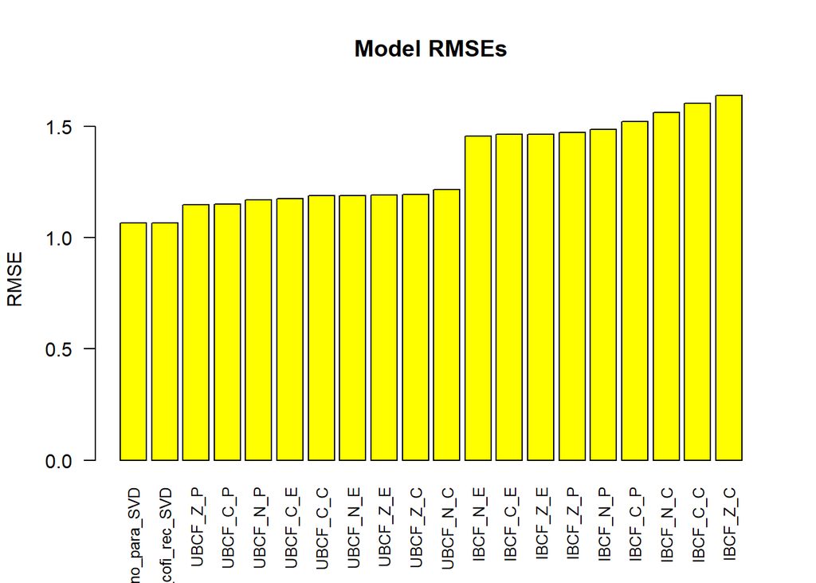

```r
barplot(c_res$RMSE, col = "yellow", main = "Model RMSEs", las = 2, ylab = "RMSE", horiz = FALSE, names.arg = rownames(c_res), cex.names=.8)
```

#### Evaluation result

It looks like the SVDs’ performance(prediction accuracy) are better than User-based and Item-based Collaborative Filtering.

#### Save pre-trained models

It takes time to train a model with large data, to save time for the App, we will store the model object to .rds format, when the system starts, it will load the .rds to the model object. it will be very fast. We save all the models we tested, it is around 20 models.

## Technical details

- Will you normalize the rating matrix? If so, which normalization option you use?  
  We let the recommenderlab do the normalization, some of our models have setting of normalization option, such as: ‘center’,“Z-score”.
- What’s the nearest neighborhood size you use?  
  The recommenderlab’s k = 3 nearest neighbors(u1, u2 and u3) are selected[9].
- Which similarity metric you use?  
  Pearson Correlation, Cosine Similarity, Euclidean Distance.
- If you say prediction is based on a “weighted average”, then explain what weights you use  
  The prediction we are using on content-based algorithm(System I) is not based on a ‘weighted average’.
- Will you still have missing values after running the algorithm? If so, how you handle those missing values?  
  Sometimes we do see missing values, I check the Michael Hahsler’s document[9], he provided a solution: if we assume users favor only a small fraction of the items and most items with not rating, this lead to the problem that we cannot compute similarities using Pearson correlation or Cosine similarity, A similarity measure which only focuses on matching ones and thus prevents the problem with zeroes is the Jaccard index.

## Movie Recommendation App

- it is a shiny app with System I and System II algorithms
- System I
  - the app needs to take the input from users on their favorite genres, and display the result
  - system will provide two methods for System I (you are able to select any of them by the setting)
- System II
  - the app need the users to rate many movies as possible;
  - system will discover movies for the users by User-based or Item-based Collaborative Filtering models or SVD models
- Setting
  - select the algorithm for System I
  - select the algorithm for System II

## Deploy the App

it is a huge challenge to deploy to Shiny server, it doesn’t support the dataset like us(1M rows), but we found a way finally to make it successfully, we are able to running the App on the full dataset, but it is not for production, it is ok for the proof of concept. We found it is stable when we work RStudio on windows environment, why don’t we use this one to demonstrate? Once we are able to change the web server port to 80, then we are able to host. We run the following code on RStudio console:

**runApp(‘app’, host = “0.0.0.0”, port = 80)**

anther thing we need to do is the server will shutdown in 1 hour, we need to ping(wget can do this job) it every 10 minutes.

## Conclusion

Multiple models were compared on the dataset, the SVD model is the top one performance. System II Collaborative Filtering is an improvement over the System I (content based recommendation system). They can take many classes of input and provide similarity ranking based algorithms to provide the user with accurate results. These recommendation systems have evolved over time and have incorporated many advanced techniques to provide users with the content they want.

> Conten-Base [10]
- Pros:
  - do not use user data, start recommending on day 1
  - can recommend new and unpopular items
  - can recommend to users with unique taste
  - easier to interpret
- Cons
  - cannot recommend outside the user’s profile
  - recommend substitute not compliment
  - finding appropriate features is diffcult

```r
Sys.time() - start_time
```

```
## Time difference of 16.80299 mins
```

## Reference

1. Piazza: https://piazza.com/class/kdf6l5f8bb78j?cid=868
2. Moviewlens: https://grouplens.org/datasets/movielens/
3. Dataset README: https://github.com/tonymazn/stat542/tree/main/data/README
4. Machine Learning Project – Data Science Movie Recommendation System Project in R https://data-flair.training/blogs/data-science-r-movie-recommendation/
5. Movie Recommendation System: https://jeknov.shinyapps.io/movieRec/
6. Item-Based Collaborative Filtering Recommendation: https://www.kaggle.com/hendraherviawan/itembased-collaborative-filter-recommendation-r
7. User-Based and Item-Based Collaborative Filtering https://rpubs.com/jt_rpubs/285729
8. Movie Recommendation System https://jeknov.shinyapps.io/movieRec/
9. Michael Hahsler: recommenderlab: A Framework for Developing and Testing Recommendation Algorithms https://cran.r-project.org/web/packages/recommenderlab/vignettes/recommenderlab.pdf
10. Lecure Nov26 https://www.youtube.com/watch?v=QMWydVg-uLg&feature=youtu.be